# PHI ARFP 2023: Introduction to R

### Bar graphs in base `R`

We’ll first use base `R` and then `ggplot2` to create the bar plots. In base `R`, you must first convert your data into a table as we have done above.

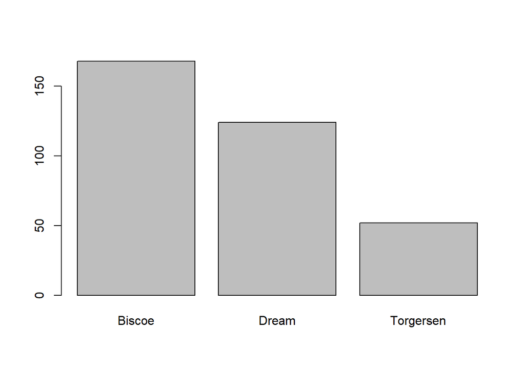

```r
#Summarize # of penguins from each
#island in a table
counts <- table(penguins$island)

#Create the plot
barplot(counts)
```

This plot tells you how many observations (a.k.a. penguins) originated from each island.

We can add some bells and whistles to this plot in base `R` as well.

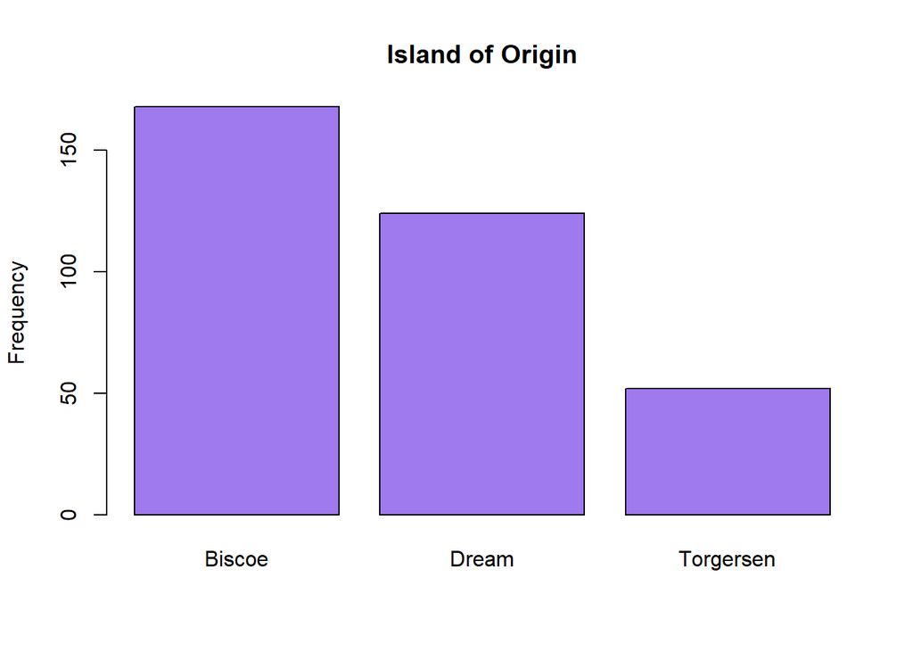

```r
barplot(counts,
        main = "Island of Origin",
        col = "mediumpurple2",
        ylab = "Frequency")
```

### Barplots in `ggplot2`

In `ggplot2`, we will use the `geom_bar()` command. In `ggplot2`, we do not need to tabulate the data prior to plotting, which is handy.

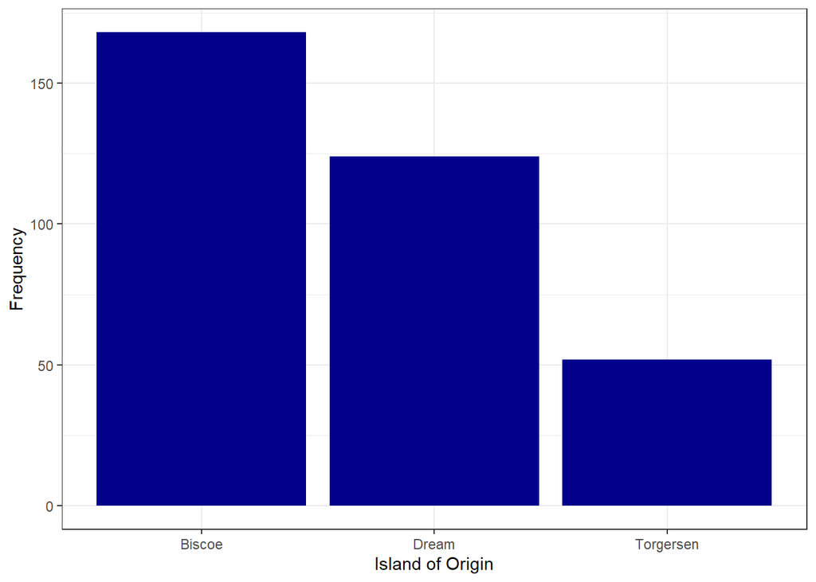

```r
ggplot(penguins, aes(x = island)) +
  geom_bar(fill = "darkblue") +
  xlab("Island of Origin") +
  ylab("Frequency") +
  theme_bw()    #note the difference in background with this theme
```

### Grouped bar plots in `ggplot2`

What if we want to observe the relationship between two categorical variables? In this case, we will examine the number of penguins of each species originating from each island. We can do so using a **grouped bar plot**. This is particularly straightforward to implement using `ggplot2`, but we will need to use `dplyr` to construct a summary tally of penguins by species and island and use that to make the graph.

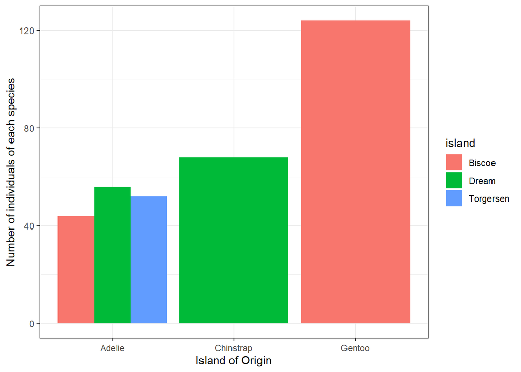

```r
#Make a quick summary table of penguins
#by island:
species_by_island <- penguins %>%
  group_by(species, island) %>%
  tally()

#Graph out the summary table using ggplot2:
ggplot(species_by_island, aes(x = species, y = n, fill = island)) +
  geom_bar(stat = "identity", position = "dodge") +
  xlab("Island of Origin") +
  ylab("Number of individuals of each species") +
  theme_bw()
```

We can also examine variable averages by group using a similar strategy as above. This time, we’ll look at average flipper length by island. Again, we need to start by manipulating the data.

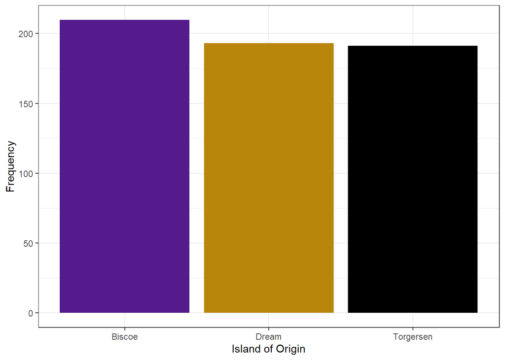

```r
#summarize average flipper length by island
flippers_by_island <- penguins %>%
  group_by(island) %>%
  summarize(mean_flipper_length = mean(flipper_length_mm, na.rm = T))

#graph it out:
ggplot(flippers_by_island, aes(x = island, y = mean_flipper_length, fill = island)) +
  geom_bar(stat = "identity", position = "dodge") +
  xlab("Island of Origin") +
  ylab("Frequency") +
  theme_bw() +
  theme(legend.position = "none")  +  #use this last line to get rid of the legend
  scale_fill_manual(values = c("purple4", "darkgoldenrod", "black"))
```

## Scatterplots in base `R`

To observe relationships between two numeric variables, we use scatterplots (also known as scattergrams). Say we want to observe the relationship between a penguin’s body mass (`body_mass_g`) and the length of its flippers (`flipper_length_mm`).

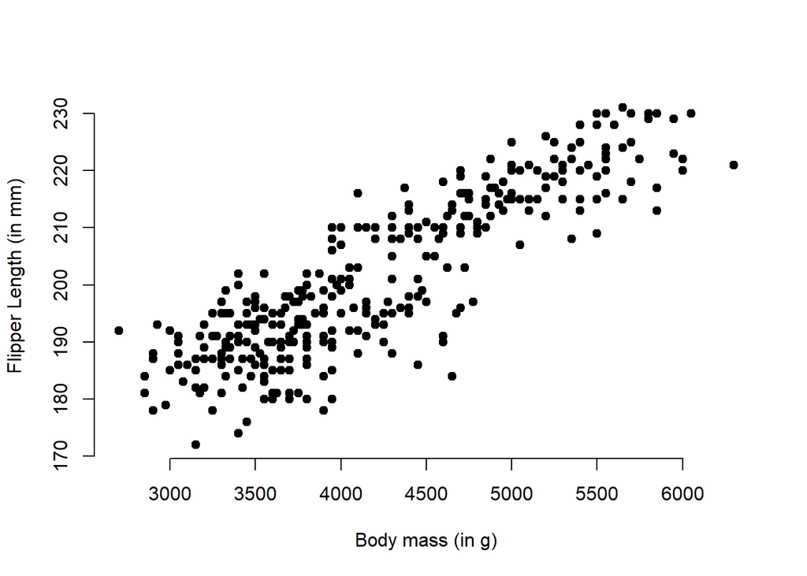

```r
plot(penguins$body_mass_g, penguins$flipper_length_mm,
     xlab = "Body mass (in g)",
     ylab = "Flipper Length (in mm)",
     frame = FALSE, #removes the boundary that R automatically puts on a scatterplot
     pch = 19)  #specifies the type of dot
```

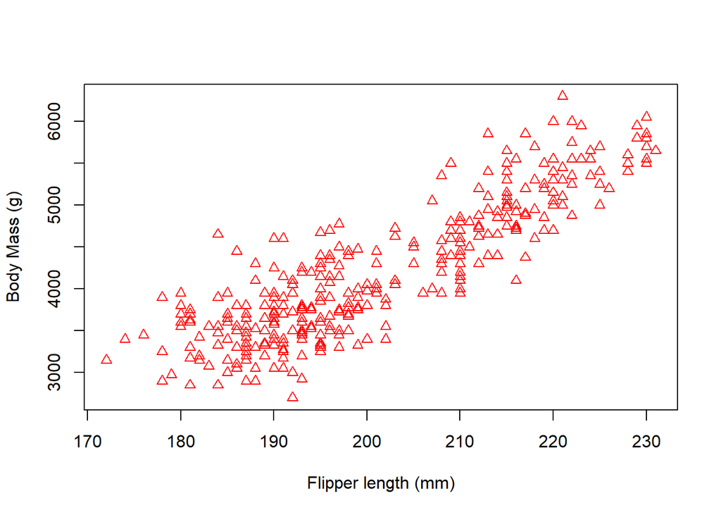

```r
plot(penguins$flipper_length_mm,
     penguins$body_mass_g,
     xlab = "Flipper length (mm)",
     ylab = "Body Mass (g)",
     main = "",
     pch = 2, col = 'red')
```

### Saving directly to `.pdf`

```r
pdf("WeightvsHeight.pdf",
    height = 4, width = 4)
plot(penguins$flipper_length_mm,
     penguins$body_mass_g,
     xlab = "Flipper length (mm)",
     ylab = "Body Mass (g)",
     main = "",
     pch = 2, col = 'red')
dev.off()
```

### Making custom plot limits

```r
max(penguins$flipper_length_mm)
```

```
## [1] NA
```

```r
max(penguins$flipper_length_mm, na.rm = TRUE)
```

```
## [1] 231
```

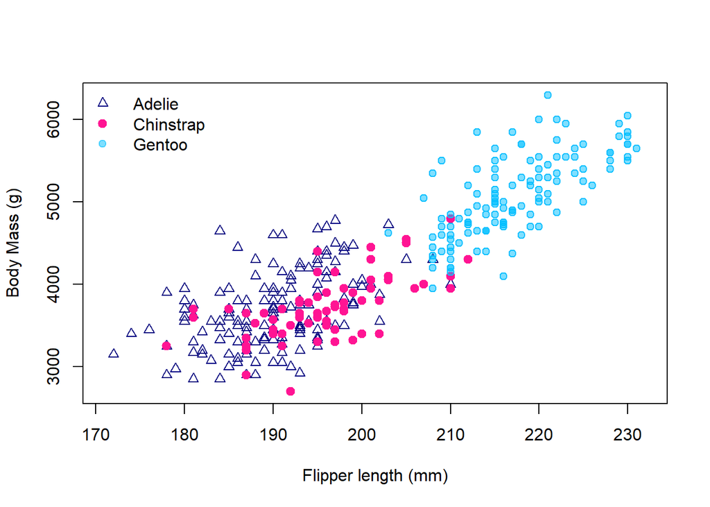

```r
xlimits <- c(min(penguins$flipper_length_mm,
                  na.rm = TRUE)-1,
              max(penguins$flipper_length_mm,
                  na.rm = TRUE)+1)
ylimits <- c(min(penguins$body_mass_g,
                  na.rm = TRUE)-1,
              max(penguins$body_mass_g,
                  na.rm = TRUE)+1)

plot(penguins$flipper_length_mm[penguins$species == "Adelie"],
     penguins$body_mass_g[penguins$species == "Adelie"],
     xlim = xlimits,
     ylim = ylimits,
     xlab = "Flipper length (mm)",
     ylab = "Body Mass (g)",
     pch = 2, col = 'navyblue')
points(penguins$flipper_length_mm[penguins$species == "Chinstrap"],
       penguins$body_mass_g[penguins$species == "Chinstrap"],
       pch = 19, col = 'deeppink',
       lwd = 2)
points(penguins$flipper_length_mm[penguins$species == "Gentoo"],
       penguins$body_mass_g[penguins$species == "Gentoo"],
       pch = 21, col = 'deepskyblue',
       bg = alpha('deepskyblue', 0.5))
legend('topleft', pch = c(2,19,19),
       lwd = c(1,2,1), lty = c(NA, NA,NA),
       col = c("navyblue",
               "deeppink",
               alpha("deepskyblue",.5)),
       legend = c("Adelie",
                  "Chinstrap",
                  "Gentoo"), bty = 'n')
```

### Multi-pane plots in base `R`

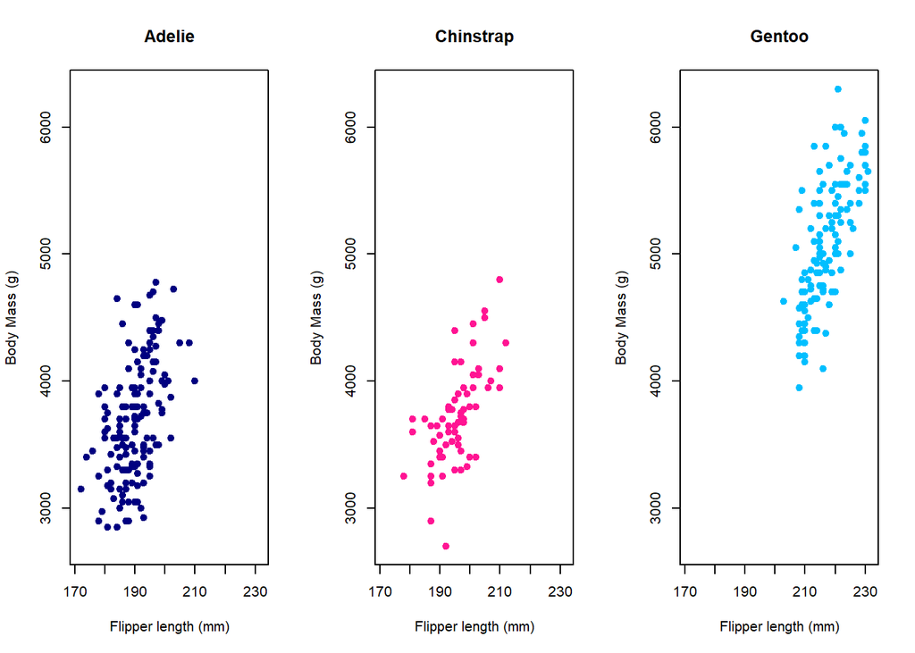

```r
par(mfrow = c(1,3))
plot(penguins$flipper_length_mm[penguins$species == "Adelie"],
     penguins$body_mass_g[penguins$species == "Adelie"],
     xlim = xlimits,
     ylim = ylimits,
     xlab = "Flipper length (mm)",
     ylab = "Body Mass (g)",
     main = "Adelie",
     pch = 19, col = 'navyblue')
plot(penguins$flipper_length_mm[penguins$species == "Chinstrap"],
     penguins$body_mass_g[penguins$species == "Chinstrap"],
     xlim = xlimits,
     ylim = ylimits,
     xlab = "Flipper length (mm)",
     ylab = "Body Mass (g)",
     main = "Chinstrap",
     pch = 19, col = 'deeppink')
plot(penguins$flipper_length_mm[penguins$species == "Gentoo"],
     penguins$body_mass_g[penguins$species == "Gentoo"],
     xlim = xlimits,
     ylim = ylimits,
     xlab = "Flipper length (mm)",
     ylab = "Body Mass (g)",
     main = 'Gentoo',
     pch = 19, col = 'deepskyblue')
```

### Multi-page pdf in base `R` with `for` loops

```r
titles <- c("Adelie", "Chinstrap", "Gentoo")
colors <- c("navyblue", "deeppink", "deepskyblue")

pdf('MassvsFlipper_species.pdf', height = 4, width = 4)
for(i in 1:3){
  par(mfrow = c(1,1))
  plot(penguins$flipper_length_mm[penguins$species == titles[i]],
     penguins$body_mass_g[penguins$species == titles[i]],
     xlim = xlimits,
     ylim = ylimits,
     xlab = "Flipper length (mm)",
     ylab = "Body Mass (g)",
     main = titles[i],
     pch = 2, col = colors[i])
}
dev.off()
```

## Scatterplots in `ggplot2`

We also might want to add a regression line to our scatterplot. While you can certainly do this in base `R`, the `ggplot2` method is given below.

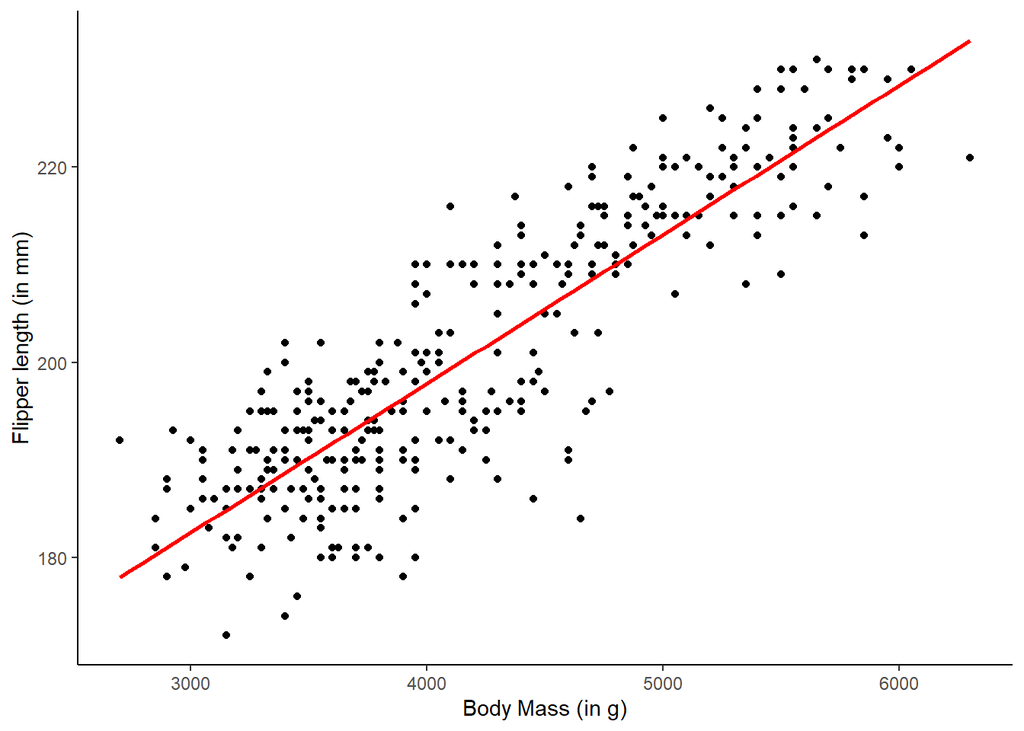

```r
ggplot(penguins, aes(x = body_mass_g, y = flipper_length_mm)) +
  geom_point() +
  xlab("Body Mass (in g)") +
  ylab("Flipper length (in mm)") +
  theme_classic() +
  geom_smooth(method = lm, color = "red", se=FALSE)
```

```r
#lm = linear model
#se = whether or not to include standard error estimates
```

### Grouped scatter plots

We can also observe how species might impact the relationship between body mass and flipper length using the grouping method. Here, we assign the dots of each species their own color. You can also distinguish categories using different levels of shading, different shapes, or even different sizes of points (https://www.r-graph-gallery.com/274-map-a-variable-to-ggplot2-scatterplot.html).

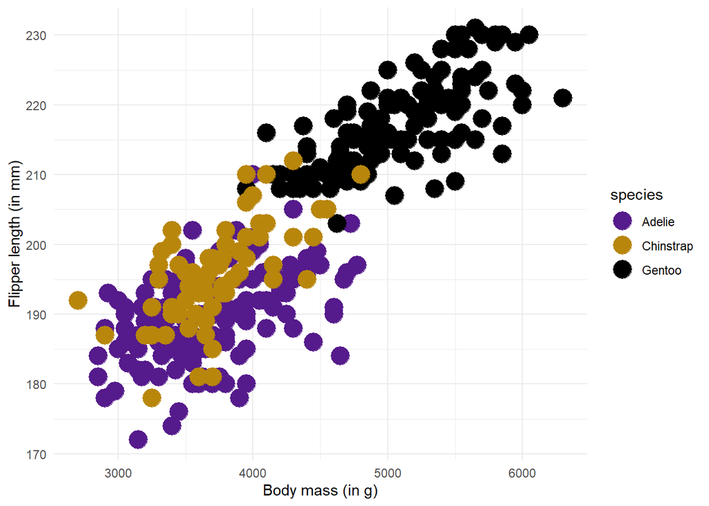

```r
ggplot(penguins, aes(x=body_mass_g, y=flipper_length_mm, color=species)) +
    geom_point(size=6) +
    theme_minimal() +
  scale_color_manual(values = c("purple4", "darkgoldenrod", "black")) +
  xlab("Body mass (in g)") +
  ylab("Flipper length (in mm)")
```

### `facet_wrap`

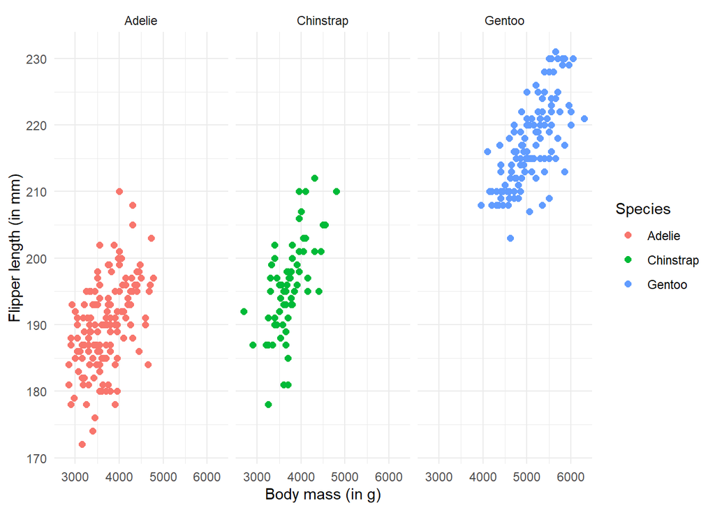

```r
penguins %>%
  ggplot(aes(x=body_mass_g, y=flipper_length_mm, color = species)) +
  geom_point(size=2) +
  facet_wrap(~species) +
  theme_minimal() +
  guides(color = guide_legend(title = "Species")) +
  xlab("Body mass (in g)") +
  ylab("Flipper length (in mm)")
```

**Question** What do you think the code below does differently than the previous example?

```r
penguins %>%
  ggplot(aes(x=body_mass_g, y=flipper_length_mm)) +
  geom_point(size=2) +
  facet_wrap(~species) +
  theme_classic() +
  xlab("Body mass (in g)") +
  ylab("Flipper length (in mm)")
```

## Saving a plot in `ggplot2`

```r
peng_plot <- penguins %>%
  ggplot(aes(x=body_mass_g, y=flipper_length_mm, color = species)) +
  geom_point(size=2) +
  facet_wrap(~species) +
  theme_minimal() +
  guides(color = guide_legend(title = "Species")) +
  xlab("Body mass (in g)") +
  ylab("Flipper length (in mm)")

ggsave(peng_plot, filename = "MassvsFlipperLength_ggplot.pdf")
```

# Practice 2: Data manipulation & Plotting

1. What is the mean bill height and depth in this dataset?
2. If 50mm is long, how many long-billed penguins are in the total dataset?
3. Create a new variable in the dataset to represent the ratio of bill length to depth.
4. Plot your new variable in a boxplot and change the color of the inside of the boxplot. HINT: see `?boxplot`.